# Preoperative Opiate Use As A Predictor Of Total-Knee Arthroplasty Revision

Jordan Starr

September 23, 2015

## Load Data & Packages

```r
library("dplyr")
library("caret")
library("ROCR")
library("scales")
alldata <- read.csv("WorkDf5.csv", sep=";")
```

## Clean Data

```r
names(alldata)
```

```
##  [1] "X"                    "Unnamed..0"           "TKAVID"
##  [4] "TKADate"              "Age"                  "gender"
##  [7] "ht"                   "wt"                   "State"
## [10] "county"               "DIVISION"             "OperationTime"
## [13] "TKASideLogical"       "NumManip"             "EarlyMnpDate"
## [16] "NumRev"               "EarlyRevDate"         "RevSideLogical"
## [19] "TimeBefore"           "TypeBefore"           "NumPillsBefore"
## [22] "TimeAfter"            "TypeAfter"            "NumPillAfter"
## [25] "sex"                  "Diabetes"             "CKD"
## [28] "HTN"                  "CHF"                  "OSA"
## [31] "PTSD"                 "Tobbaco"              "PostSurgProc"
## [34] "OpioidsBeforeLogical" "CentNumPillsBefore"   "OpioidsAfterLogical"
## [37] "CentNumPillsAfter"    "ManipLogical"         "RevLogical"
## [40] "NumRevLogical"        "IfAfter"              "IfBefore"
## [43] "TKADate2"             "TKAYear"              "TKAVID.1"
## [46] "TKADate.1"            "med_load"             "chronic"
## [49] "t2rev"
```

Remove unnecessary columns

```r
data <- alldata[,c(5:8,19,26:32,39,47)]
str(data)
```

```
## 'data.frame':    33642 obs. of  14 variables:
##  $ Age       : int  62 61 59 80 84 74 64 62 64 64 ...
##  $ gender    : Factor w/ 2 levels "F","M": 2 2 2 2 2 2 2 2 2 2 ...
##  $ ht        : num  0 72 65 65 64 71 71.5 68.5 62 69 ...
##  $ wt        : num  0 217 185 152 217 ...
##  $ TimeBefore: int  4 11 9 12 5 11 11 7 0 8 ...
##  $ Diabetes  : int  0 0 1 1 1 0 0 0 1 1 ...
##  $ CKD       : int  0 0 0 0 1 1 0 0 0 0 ...
##  $ HTN       : int  1 0 1 1 1 1 1 1 0 0 ...
##  $ CHF       : int  1 0 1 1 1 1 1 1 0 0 ...
##  $ OSA       : int  0 0 0 0 0 0 0 0 0 0 ...
##  $ PTSD      : int  0 0 0 0 0 0 0 0 0 1 ...
##  $ Tobbaco   : int  0 0 0 0 0 0 0 0 0 0 ...
##  $ RevLogical: int  0 0 0 0 0 0 0 0 0 0 ...
##  $ med_load  : num  270 1200 150 1200 612 ...
```

Set correct variable types

```r
data$Diabetes <- as.factor(data$Diabetes)
data$CKD <- as.factor(data$CKD)
data$HTN <- as.factor(data$HTN)
data$CHF <- as.factor(data$CHF)
data$OSA <- as.factor(data$OSA)
data$PTSD <- as.factor(data$PTSD)
data$Tobbaco <- as.factor(data$Tobbaco)
data$RevLogical <- as.factor(data$RevLogical)
```

Check distribution of height variable, remove spurious values.

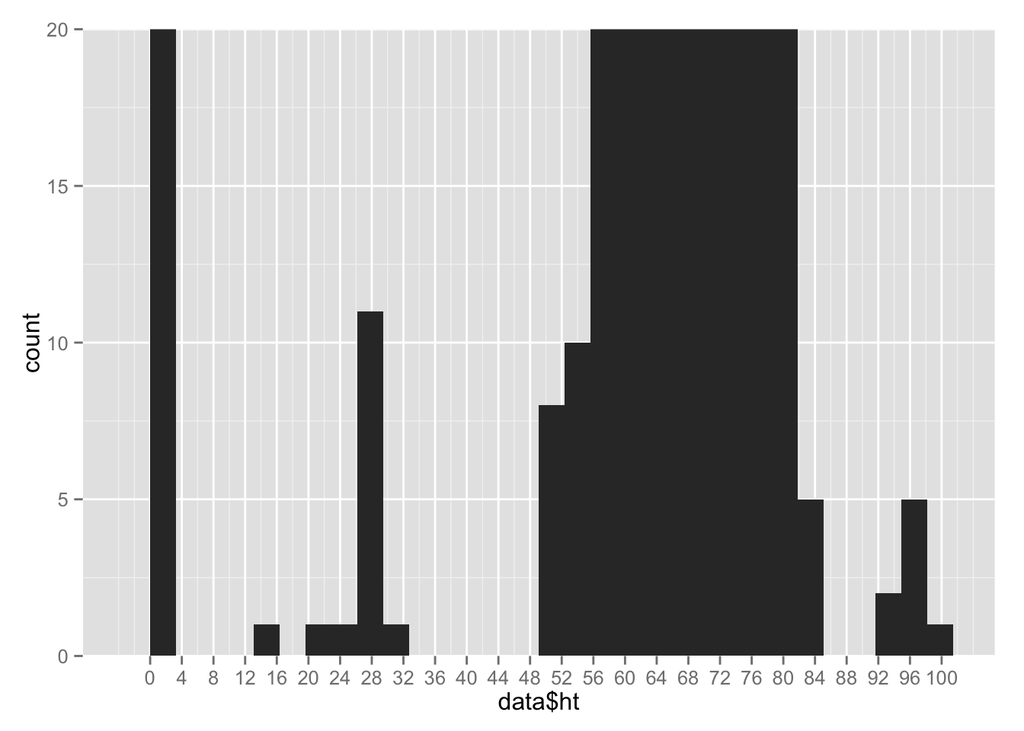

```r
ggplot(data=data, aes(data$ht)) + geom_histogram() + coord_cartesian(ylim=c(0, 20)) + scale_x_continuous(breaks=seq(0, 100, 4))
```

```r
data$ht <- ifelse(data$ht < 48 | data$ht > 86, NA, data$ht)
```

Check distribution of weight variable, remove spuriuos values.

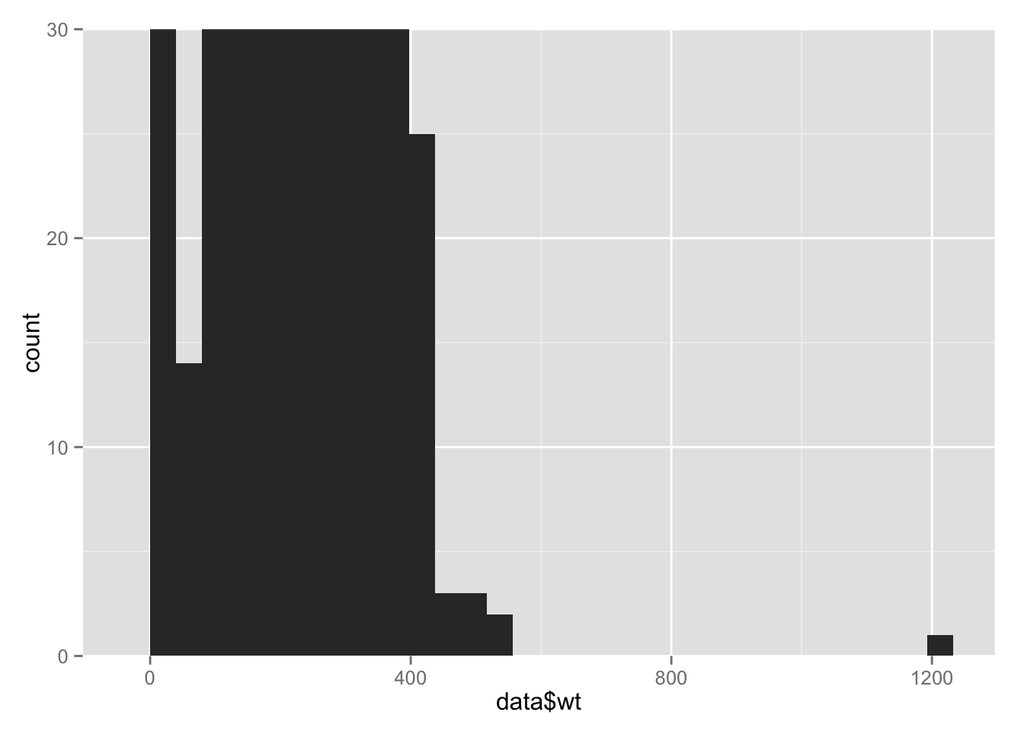

```r
ggplot(data=data, aes(data$wt)) + geom_histogram() + coord_cartesian(ylim=c(0, 30))
```

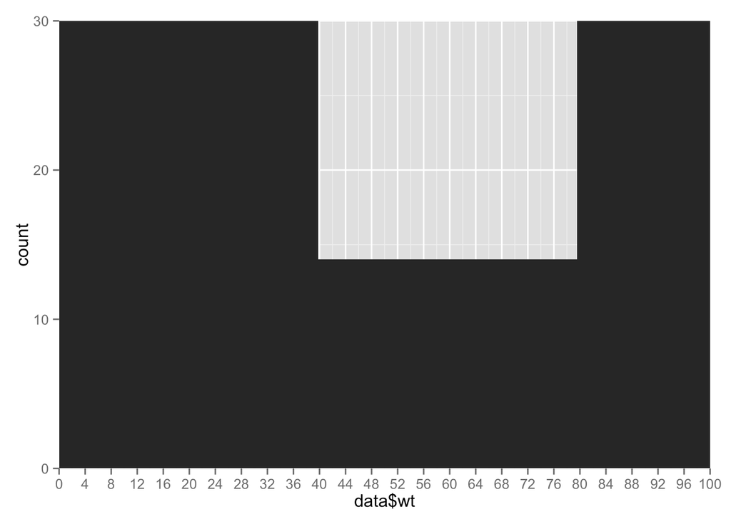

```r
ggplot(data=data, aes(data$wt)) + geom_histogram() + coord_cartesian(ylim=c(0, 30),xlim=c(0,100)) + scale_x_continuous(breaks=seq(0, 100, 4))
```

```r
data$wt <- ifelse(data$wt < 80 | data$wt > 600, NA, data$wt)
```

Create BMI variable:

```r
data <- mutate(data, BMI = (wt/2.2)/(ht*2.54/100)^2)
```

Create morphine equivalent dose per month variable:

```r
data$MEDperMonth <- ifelse(data$TimeBefore==0, 0, data$med_load/data$TimeBefore)
```

Check MEDperMonth distribution and remove significant outliers:

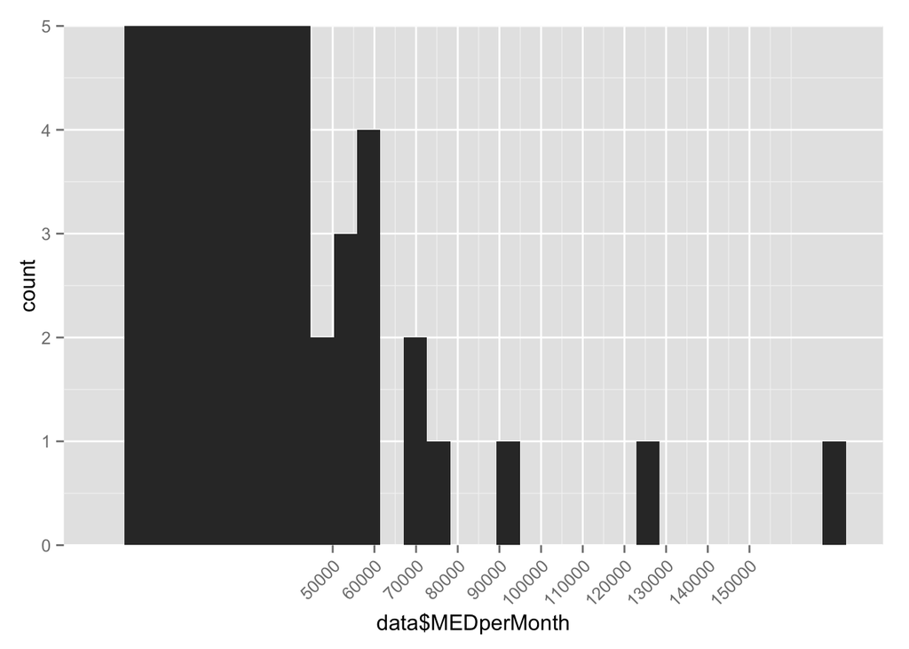

```r
ggplot(data=data, aes(data$MEDperMonth)) + geom_histogram() + coord_cartesian(ylim=c(0,5)) + scale_x_continuous(breaks=seq(50000,150000,10000))+theme(axis.text.x = element_text(angle = 45, hjust = 1))
```

```r
data$MEDperMonth <- ifelse(data$MEDperMonth > 80000, NA, data$MEDperMonth)
```

Convert dependent variable to usable factors for future probability functions:

```r
data$RevLogical <- factor(data$RevLogical, levels = c(0,1),labels = c("no", "yes"))
```

```r
summary(data)
```

```
##       Age        gender          ht              wt
##  Min.   :24.00   F: 1888   Min.   :50.00   Min.   : 82.73
##  1st Qu.:58.00   M:31754   1st Qu.:68.00   1st Qu.:190.60
##  Median :63.00             Median :70.00   Median :217.00
##  Mean   :64.36             Mean   :69.71   Mean   :220.73
##  3rd Qu.:71.00             3rd Qu.:72.00   3rd Qu.:247.00
##  Max.   :96.00             Max.   :84.00   Max.   :554.00
##                            NA's   :4743    NA's   :844
##    TimeBefore     Diabetes  CKD       HTN       CHF       OSA
##  Min.   : 0.000   0:22976   0:30803   0:11393   0:11128   0:31661
##  1st Qu.: 0.000   1:10666   1: 2839   1:22249   1:22514   1: 1981
##  Median : 5.000
##  Mean   : 6.881
##  3rd Qu.:11.000
##  Max.   :70.000
##
##  PTSD      Tobbaco   RevLogical     med_load            BMI
##  0:28148   0:32667   no :31927   Min.   :      0   Min.   :12.45
##  1: 5494   1:  975   yes: 1715   1st Qu.:      0   1st Qu.:27.97
##                                  Median :    300   Median :31.45
##                                  Mean   :   7076   Mean   :32.01
##                                  3rd Qu.:   2970   3rd Qu.:35.45
##                                  Max.   :3685800   Max.   :89.61
##                                                    NA's   :4781
##   MEDperMonth
##  Min.   :    0.00
##  1st Qu.:    0.00
##  Median :   40.62
##  Mean   :  426.55
##  3rd Qu.:  300.00
##  Max.   :75000.00
##  NA's   :3
```

Remove ht and wt columns (already in BMI), remove med_load and TimeBefore (accounted for in MEDperMonth), and then trim dataset of NAs

```r
cleandata <- data[,c(-3:-5,-14)]
z <- nrow(cleandata[!complete.cases(cleandata),])
z # Number of cases with missing values
```

```
## [1] 4784
```

```r
100*z/nrow(cleandata) # Percent of cases with missing values
```

```
## [1] 14.22032
```

```r
completeData <- na.omit(cleandata)
```

## Data Analysis

### Typical Logistic Regression Model

With all variables, in order of significance, younger age, CKD, DM, opiate use, lower BMI, not smoking, and CHF redict TKA revision.

```r
glmfitall <- glm(RevLogical ~ ., data = completeData, family = "binomial")
summary(glmfitall)
```

```
##
## Call:
## glm(formula = RevLogical ~ ., family = "binomial", data = completeData)
##
## Deviance Residuals:
##     Min       1Q   Median       3Q      Max
## -0.8123  -0.3537  -0.3073  -0.2508   3.0193
##
## Coefficients:
##               Estimate Std. Error z value Pr(>|z|)
## (Intercept)  3.814e-01  2.745e-01   1.389  0.16475
## Age         -5.155e-02  3.148e-03 -16.374  < 2e-16 ***
## genderM      1.628e-01  1.149e-01   1.416  0.15666
## Diabetes1    1.914e-01  6.072e-02   3.153  0.00162 **
## CKD1         4.706e-01  9.039e-02   5.206 1.93e-07 ***
## HTN1        -4.707e-01  2.477e-01  -1.900  0.05742 .
## CHF1         5.188e-01  2.510e-01   2.067  0.03877 *
## OSA1        -6.802e-03  1.105e-01  -0.062  0.95092
## PTSD1        8.128e-02  6.827e-02   1.191  0.23380
## Tobbaco1    -4.180e-01  1.859e-01  -2.249  0.02452 *
## BMI         -1.251e-02  4.928e-03  -2.539  0.01112 *
## MEDperMonth  2.506e-05  8.485e-06   2.954  0.00314 **
## ---
## Signif. codes:  0 '***' 0.001 '**' 0.01 '*' 0.05 '.' 0.1 ' ' 1
##
## (Dispersion parameter for binomial family taken to be 1)
##
##     Null deviance: 11622  on 28857  degrees of freedom
## Residual deviance: 11301  on 28846  degrees of freedom
## AIC: 11325
##
## Number of Fisher Scoring iterations: 6
```

These are the odds ratios and associated 95% confidence intervals.

```r
exp(coef(glmfitall)) # Odds ratios
```

```
## (Intercept)         Age     genderM   Diabetes1        CKD1        HTN1
##   1.4643242   0.9497536   1.1767426   1.2109827   1.6009155   0.6245698
##        CHF1        OSA1       PTSD1    Tobbaco1         BMI MEDperMonth
##   1.6800220   0.9932214   1.0846787   0.6583789   0.9875654   1.0000251
```

```r
exp(confint(glmfitall)) # Confidence intervals
```

```
##                 2.5 %    97.5 %
## (Intercept) 0.8534145 2.5036490
## Age         0.9438987 0.9556207
## genderM     0.9451084 1.4836265
## Diabetes1   1.0746480 1.3634771
## CKD1        1.3367883 1.9056581
## HTN1        0.3945384 1.0449809
## CHF1        0.9987483 2.6799134
## OSA1        0.7951042 1.2267236
## PTSD1       0.9473774 1.2381836
## Tobbaco1    0.4480608 0.9307398
## BMI         0.9780270 0.9971048
## MEDperMonth 1.0000071 1.0000407
```

While the odds ratio for opiate use appears small, this is for one morphine equivalent per month. To add context:

```r
# Here is the baseline absolute risk* of revision in opiate naive patients:
u <- subset(completeData, MEDperMonth == 0)
percent(length(u$RevLogical[u$RevLogical == "yes"])/length(u$RevLogical))
```

```
## [1] "3.92%"
```

```r
# For a hypothetical patient on oxycodone 5 mg q6h PRN (assuming an oxycodone to morphine ratio of 2:3 in a 31-day month), they would have the following number of morphine equivalents per month:
5*1.5*4*31
```

```
## [1] 930
```

```r
# Using our model, this patient's relative risk of TKA revision increases by the following amount:
percent((2.506e-05*930)/ (length(u$RevLogical[u$RevLogical == "yes"])/length(u$RevLogical)))
```

```
## [1] "59.4%"
```

*Despite this being a retrospective analysis, we are interpretting our results as probabilities given the low frequency of TKA revision.*

```r
glmfit1 <- glm(RevLogical ~ Age, data = completeData, family = "binomial")
glmfit2 <- glm(RevLogical ~ Age + CKD, data = completeData, family = "binomial")
glmfit3 <- glm(RevLogical ~ Age + CKD + Diabetes, data = completeData, family = "binomial")
glmfit4 <- glm(RevLogical ~ Age + CKD + Diabetes + MEDperMonth, data = completeData, family = "binomial")
glmfit5 <- glm(RevLogical ~ Age + CKD + Diabetes + MEDperMonth + BMI, data = completeData, family = "binomial")
glmfit6 <- glm(RevLogical ~ Age + CKD + Diabetes + MEDperMonth + BMI + Tobbaco, data = completeData, family = "binomial")
glmfit7 <- glm(RevLogical ~ Age + CKD + Diabetes + MEDperMonth + BMI + Tobbaco + CHF, data = completeData, family = "binomial")
anova(glmfit1, glmfit2, glmfit3, glmfit4, glmfit5, glmfit6, glmfit7, test = "Chisq")
```

```
## Analysis of Deviance Table
##
## Model 1: RevLogical ~ Age
## Model 2: RevLogical ~ Age + CKD
## Model 3: RevLogical ~ Age + CKD + Diabetes
## Model 4: RevLogical ~ Age + CKD + Diabetes + MEDperMonth
## Model 5: RevLogical ~ Age + CKD + Diabetes + MEDperMonth + BMI
## Model 6: RevLogical ~ Age + CKD + Diabetes + MEDperMonth + BMI + Tobbaco
## Model 7: RevLogical ~ Age + CKD + Diabetes + MEDperMonth + BMI + Tobbaco +
##     CHF
##   Resid. Df Resid. Dev Df Deviance  Pr(>Chi)
## 1     28856      11367
## 2     28855      11337  1  29.7887 4.818e-08 ***
## 3     28854      11328  1   8.5042  0.003543 **
## 4     28853      11321  1   7.6120  0.005798 **
## 5     28852      11315  1   6.1735  0.012968 *
## 6     28851      11309  1   5.6115  0.017843 *
## 7     28850      11308  1   0.9781  0.322674
## ---
## Signif. codes:  0 '***' 0.001 '**' 0.01 '*' 0.05 '.' 0.1 ' ' 1
```

With this approach, which shows glmfit6 to be the optimal model, the following variables are kept for predicting revision: age, CKD, DM, opiate use, lower BMI, and tobacco.

```r
summary(glmfit6)
```

```
##
## Call:
## glm(formula = RevLogical ~ Age + CKD + Diabetes + MEDperMonth +
##     BMI + Tobbaco, family = "binomial", data = completeData)
##
## Deviance Residuals:
##     Min       1Q   Median       3Q      Max
## -0.7957  -0.3528  -0.3073  -0.2523   3.0157
##
## Coefficients:
##               Estimate Std. Error z value Pr(>|z|)
## (Intercept)  5.210e-01  2.566e-01   2.030 0.042349 *
## Age         -5.072e-02  3.074e-03 -16.501  < 2e-16 ***
## CKD1         4.832e-01  8.978e-02   5.382 7.37e-08 ***
## Diabetes1    2.103e-01  5.920e-02   3.551 0.000383 ***
## MEDperMonth  2.549e-05  8.438e-06   3.020 0.002524 **
## BMI         -1.234e-02  4.865e-03  -2.536 0.011218 *
## Tobbaco1    -4.141e-01  1.858e-01  -2.229 0.025845 *
## ---
## Signif. codes:  0 '***' 0.001 '**' 0.01 '*' 0.05 '.' 0.1 ' ' 1
##
## (Dispersion parameter for binomial family taken to be 1)
##
##     Null deviance: 11622  on 28857  degrees of freedom
## Residual deviance: 11309  on 28851  degrees of freedom
## AIC: 11323
##
## Number of Fisher Scoring iterations: 6
```

```r
exp(coef(glmfit6)) # Odds ratios
```

```
## (Intercept)         Age        CKD1   Diabetes1 MEDperMonth         BMI
##   1.6837322   0.9505427   1.6212102   1.2339949   1.0000255   0.9877385
##    Tobbaco1
##   0.6609407
```

```r
exp(confint(glmfit6)) # Confidence intervals
```

```
##                 2.5 %    97.5 %
## (Intercept) 1.0174474 2.7826145
## Age         0.9448195 0.9562738
## CKD1        1.3552913 1.9273720
## Diabetes1   1.0982574 1.3851946
## MEDperMonth 1.0000076 1.0000411
## BMI         0.9783200 0.9971566
## Tobbaco1    0.4498406 0.9342680
```

Using the same methods as above, the following relative risk increase for a hypothetical patient using oxycodone can be calculated from this slightly simpler model.

```r
percent((2.549e-05*930)/ (length(u$RevLogical[u$RevLogical == "yes"])/length(u$RevLogical)))
```

```
## [1] "60.5%"
```

### Machine Learning Models

Training, testing, and validation datasets:

```
inTrain <- createDataPartition(y=completeData$RevLogical, p = .6, list=FALSE)
training <- completeData[inTrain, ]
testingboth <- completeData[-inTrain, ]
inTrain2 <- createDataPartition(y=testingboth$RevLogical, p = .5, list =F)
testing <- testingboth[inTrain2,]
validation <- testingboth[-inTrain2,]
```

GLM with 10-fold cross validation (AUC = 0.621)

```
ctrl <- trainControl(method="cv", number=10, classProbs = TRUE)
glmfit <- train(RevLogical ~ ., data = training, method="glm", trControl = ctrl)
pred1 <- predict(glmfit, testing, type="prob")
x <- prediction(pred1[,2],testing$RevLogical)
y <- performance(x, measure = "tpr", x.measure = "fpr")
plot(y)
abline(a=0, b= 1)
z <- performance(x, measure = "auc")
z@y.values
```

Rpart Tree (AUC = 0.5)

```
rpartfit <- train(RevLogical ~ ., data = training, method="rpart")
pred <- predict(rpartfit, testing, type="prob")
x <- prediction(pred[,2],testing$RevLogical)
y <- performance(x, measure = "tpr", x.measure = "fpr")
plot(y)
abline(a=0, b= 1)
z <- performance(x, measure = "auc")
z@y.values
```

Boosting (AUC = 0.641)

```
gbmfit <- train(RevLogical ~ ., data = training, method="gbm", verbose = F)
pred2 <- predict(gbmfit, testing, type="prob")
x <- prediction(pred2[,2],testing$RevLogical)
y <- performance(x, measure = "tpr", x.measure = "fpr")
plot(y)
abline(a=0, b= 1)
z <- performance(x, measure = "auc")
z@y.values
```

Linear Discriminant Analysis (AUC = 0.623)

```
ldafit <- train(RevLogical ~ ., data = training, method="lda")
pred3 <- predict(ldafit, testing, type="prob")
x <- prediction(pred3[,2],testing$RevLogical)
y <- performance(x, measure = "tpr", x.measure = "fpr")
plot(y)
abline(a=0, b= 1)
z <- performance(x, measure = "auc")
z@y.values
```

Naive Bayes (AUC = 0.603)

```
nbfit <- train(RevLogical ~ ., data = training, method="nb")
pred4 <- predict(nbfit, testing, type="prob")
x <- prediction(pred4[,2],testing$RevLogical)
y <- performance(x, measure = "tpr", x.measure = "fpr")
plot(y)
abline(a=0, b= 1)
z <- performance(x, measure = "auc")
z@y.values
```

```
ctrl <- trainControl(method="cv", number=10)
rffitall <- train(training[,-10], training$RevLogical, method="rf", prox=T, trControl = ctrl)
pred5 <- predict(rffitall, testing, type="prob")
x <- prediction(pred5[,2],testing$RevLogical)
y <- performance(x, measure = "tpr", x.measure = "fpr")
plot(y)
abline(a=0, b= 1)
z <- performance(x, measure = "auc")
z@y.values
```

[output not shown]

```
predDF <- data.frame(pred1, pred2, pred3, pred4, pred5, RevLogical = testing$RevLogical)
combModFit <- train(RevLogical ~ ., data = predDF, method = "gam")
combPred <- predict(combModFit, predDF)
pred1V <- predict(pred1, validation)
pred2V <- predict(pred2, validation)
pred3V <- predict(pred3, validation)
pred4V <- predict(pred4, validation)
pred5V <- predict(pred5, validation)
predVDF <- data.frame(pred1V, pred2V, pred3V, pred4V, pred5V)
combPredV <- predict(combModFit, predVDF)
x <- prediction(combPredV[,2],validation$RevLogical)
y <- performance(x, measure = "tpr", x.measure = "fpr")
plot(y)
abline(a=0, b= 1)
z <- performance(x, measure = "auc")
z@y.values
```